# wk6 DAIA EDA exercise

## Introduction Exercise Exploratory Data Analysis

This notebook contains an exercise to deepen your knowledge and skills to explore and analyse data, in order to understand the data (better).

## Background Resources

### Python Visualization Landscape

- [Python Visualization Landscape- PyViz](https://pyviz.org/overviews/index.html)

### Data Visualization

- [from Data to Viz](https://www.data-to-viz.com/)
- [The Python Graph Gallery - Python Graph Gallery](https://python-graph-gallery.com/) (The code is often not the most elegant ...)

### Matplotlib

- [Understanding Matplotlib: Subplots, Axes, and Axis - SaturnCloud](https://saturncloud.io/blog/understanding-matplotlib-subplots-axes-and-axis/)
- [Creating multiple subplots using plt.subplots - Matplotlib Documentation](https://matplotlib.org/stable/gallery/subplots_axes_and_figures/subplots_demo.html)

### Pandas

- [Chart visualization - PyData pandas documentation](https://pandas.pydata.org/docs/user_guide/visualization.html)
- [How do I create plots in pandas? - PyData pandas documentation](https://pandas.pydata.org/docs/getting_started/intro_tutorials/04_plotting.html)
- [Plot With pandas: Python Data Visualization for Beginners - Real Python](https://realpython.com/pandas-plot-python/)
- [How to Plot a DataFrame Using Pandas - DATAQUEST](https://www.dataquest.io/blog/plot-dataframe-pandas/)
- [Guide to Data Visualization in Python with Pandas - StackAbuse](https://stackabuse.com/introduction-to-data-visualization-in-python-with-pandas/)
- [Table Visualization - PyData pandas documentation](https://pandas.pydata.org/docs/user_guide/style.html) Styling tables is yet another way to present data in an intuitive and user friendly way that makes it easy to interpret your analysis results. We do not (yet) cover it in this course, but you are of course free to use it.

### Seaborn

- [Seaborn Tutorial - DataCamp](https://www.datacamp.com/tutorial/seaborn-python-tutorial)
- [Seaborn Cheat Sheet - DataCamp](https://images.datacamp.com/image/upload/v1676302629/Marketing/Blog/Seaborn_Cheat_Sheet.pdf)
- [Seaborn Cheat Sheet - Amazon Web Services](https://s3.amazonaws.com/assets.datacamp.com/blog_assets/Python_Seaborn_Cheat_Sheet.pdf) (same sheet, different markup)
- [Python Seaborn Tutorial - GeeksforGeeks](https://www.geeksforgeeks.org/python-seaborn-tutorial/)
- [Introduction to Seaborn - GeeksforGeeks](https://www.geeksforgeeks.org/introduction-to-seaborn-python/)
- [Seaborn Tutorial - tutorialspoint](https://www.tutorialspoint.com/seaborn/index.htm)
- [Seaborn tutorial - mlnuggets](https://www.machinelearningnuggets.com/seaborn-tutorial/)
- [Seaborn Tutorial in Python For Beginners - Great Learning](https://www.mygreatlearning.com/blog/seaborn-tutorial/)
- [An Introduction to the Seaborn Objects System - Anaconda](https://anaconda.cloud/seaborn-objects-system)

```python
import pandas as pd
import seaborn as sns
import matplotlib.pyplot as plt
```

## Titanic Revisited - Analyzing Missing Data

```python
df = sns.load_dataset('titanic', cache=False)
df
```

|  | survived | pclass | sex | age | sibsp | parch | fare | embarked | class | who | adult_male | deck | embark_town | alive | alone |
| --- | --- | --- | --- | --- | --- | --- | --- | --- | --- | --- | --- | --- | --- | --- | --- |
| 0 | 0 | 3 | male | 22.0 | 1 | 0 | 7.2500 | S | Third | man | True | NaN | Southampton | no | False |
| 1 | 1 | 1 | female | 38.0 | 1 | 0 | 71.2833 | C | First | woman | False | C | Cherbourg | yes | False |
| 2 | 1 | 3 | female | 26.0 | 0 | 0 | 7.9250 | S | Third | woman | False | NaN | Southampton | yes | True |
| 3 | 1 | 1 | female | 35.0 | 1 | 0 | 53.1000 | S | First | woman | False | C | Southampton | yes | False |
| 4 | 0 | 3 | male | 35.0 | 0 | 0 | 8.0500 | S | Third | man | True | NaN | Southampton | no | True |
| ... | ... | ... | ... | ... | ... | ... | ... | ... | ... | ... | ... | ... | ... | ... | ... |
| 886 | 0 | 2 | male | 27.0 | 0 | 0 | 13.0000 | S | Second | man | True | NaN | Southampton | no | True |
| 887 | 1 | 1 | female | 19.0 | 0 | 0 | 30.0000 | S | First | woman | False | B | Southampton | yes | True |
| 888 | 0 | 3 | female | NaN | 1 | 2 | 23.4500 | S | Third | woman | False | NaN | Southampton | no | False |
| 889 | 1 | 1 | male | 26.0 | 0 | 0 | 30.0000 | C | First | man | True | C | Cherbourg | yes | True |
| 890 | 0 | 3 | male | 32.0 | 0 | 0 | 7.7500 | Q | Third | man | True | NaN | Queenstown | no | True |

891 rows × 15 columns

```python
df.info()
```

```
<class 'pandas.core.frame.DataFrame'>
RangeIndex: 891 entries, 0 to 890
Data columns (total 15 columns):
 #   Column       Non-Null Count  Dtype
---  ------       --------------  -----
 0   survived     891 non-null    int64
 1   pclass       891 non-null    int64
 2   sex          891 non-null    object
 3   age          714 non-null    float64
 4   sibsp        891 non-null    int64
 5   parch        891 non-null    int64
 6   fare         891 non-null    float64
 7   embarked     889 non-null    object
 8   class        891 non-null    category
 9   who          891 non-null    object
 10  adult_male   891 non-null    bool
 11  deck         203 non-null    category
 12  embark_town  889 non-null    object
 13  alive        891 non-null    object
 14  alone        891 non-null    bool
dtypes: bool(2), category(2), float64(2), int64(4), object(5)
memory usage: 80.7+ KB
```

We have already established that the variable `age` lacks quite some values and now we want to see if that is somehow related to values of other variables in the same observation. We are especially interested in the relations between `age` and the variables `pclass`, `sex` and `embarked`.

`pclass` is stored as an integer, but it is actually a nominal (categorical) variable. Because chartting engines are often lead in chosing optimal visuals by data types, lets convert `pclass` to its proper type.

```python
df['pclass'] = df['pclass'].astype('category')
```

Let's first investigate the relationship between `age` and `pclass`. We're mainly interested in the ratio of nulls and non-nulls per category key:

```python
df.groupby('pclass', observed=False).agg(count=('age', 'count'), size=('age', 'size')).assign(nulls=lambda x: x['size'] - x['count'])
```

| pclass | count | size | nulls |
| --- | --- | --- | --- |
| 1 | 186 | 216 | 30 |
| 2 | 173 | 184 | 11 |
| 3 | 355 | 491 | 136 |

It's a matter of personal taste, but I prefer to chain methods vertically:

```python
(
    df
    .groupby('pclass', observed=False)
    .agg(count=('age', 'count'), size=('age', 'size'))
    .assign(nulls=lambda x: x['size'] - x['count'])
)
```

| pclass | count | size | nulls |
| --- | --- | --- | --- |
| 1 | 186 | 216 | 30 |
| 2 | 173 | 184 | 11 |
| 3 | 355 | 491 | 136 |

Alternatively, using lambda's as aggregate functions:

```python
(
    df
    .groupby('pclass', observed=False)
    .agg(avail=('age', lambda x: x.notnull().sum()), missing=('age', lambda x: x.isnull().sum()))
)
```

| pclass | avail | missing |
| --- | --- | --- |
| 1 | 186 | 30 |
| 2 | 173 | 11 |
| 3 | 355 | 136 |

Knowing per `pclass` key what percentage of `age`s is avaialble and what is missing, gives even more insight:

```python
(
    df
    .groupby('pclass', observed=False)
    .agg(avail=('age', lambda x: x.notnull().mean()), missing=('age', lambda x: x.isnull().mean()))
)
```

| pclass | avail | missing |
| --- | --- | --- |
| 1 | 0.861111 | 0.138889 |
| 2 | 0.940217 | 0.059783 |
| 3 | 0.723014 | 0.276986 |

This is something worthwile to visualize. Because the values we want to display on the y-axis are spread over two variables, we opt for pandas plotting as pandas is capable to plot values from wide format tables:

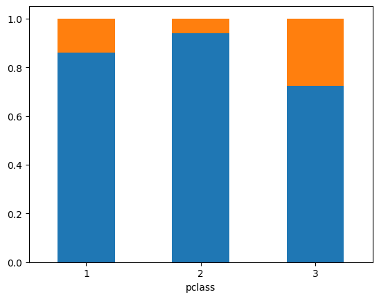

```python
(
    df
    .groupby('pclass', observed=False)
    .agg(avail=('age', lambda x: x.notnull().mean()), missing=('age', lambda x: x.isnull().mean()))
    .plot.bar(stacked=True, legend=False, rot=0)
);
```

If we want to use Seaborn, we first have to transform the table from wide to long format. Also we have to turn the index into a real variable (column).

```python
(
    df
    .groupby('pclass', observed=False)
    .agg(avail=('age', lambda x: x.notnull().mean()), missing=('age', lambda x: x.isnull().mean()))
    .stack()
    .reset_index()
    .rename(columns={'level_1': 'kind', 0: 'prop'})
)
```

|  | pclass | kind | prop |
| --- | --- | --- | --- |
| 0 | 1 | avail | 0.861111 |
| 1 | 1 | missing | 0.138889 |
| 2 | 2 | avail | 0.940217 |
| 3 | 2 | missing | 0.059783 |
| 4 | 3 | avail | 0.723014 |
| 5 | 3 | missing | 0.276986 |

But as is always the case in pandas, there is an alternative and in my opinion cleaner way to go from wide to long format in pandas:

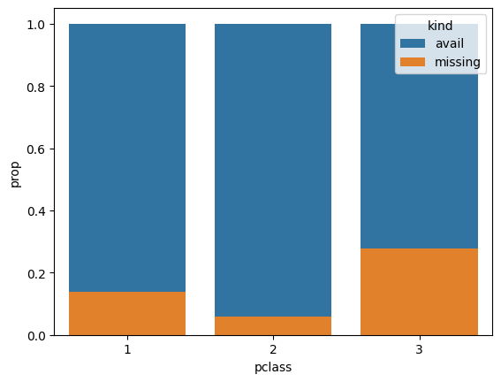

```python
(
    df
    .groupby('pclass', observed=False, as_index=False)
    .agg(missing=('age', lambda x: x.isnull().mean()))
    .assign(avail=1)
    .melt(id_vars='pclass', value_vars=['avail', 'missing'], var_name='kind', value_name='prop')
    .pipe(sns.barplot, x='pclass', y='prop', hue='kind', dodge=False)
)
```

Now let's do this for three variables in the same plot (figure):

```python
categories = ['pclass', 'sex', 'embarked']
```

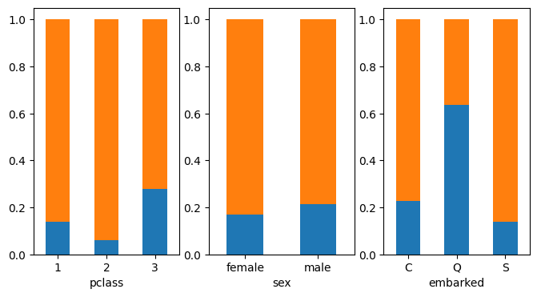

```python
fig, axes = plt.subplots(ncols=len(categories), figsize=(8,4))

for i, cat in enumerate(categories):
    (
        df
        .groupby(cat, observed=False)
        .agg(missing=('age', lambda x: x.isnull().mean()), avail=('age', lambda x: x.notnull().mean()))
        .plot.bar(stacked=True, legend=False, rot=0, ax=axes[i])
    )

# fig.tight_layout()
```

Now, if you think about it, the stacking to 100% is not really adding informtion. It's the difference in proportion of missing values for each category key that bears all information that we are interested in:

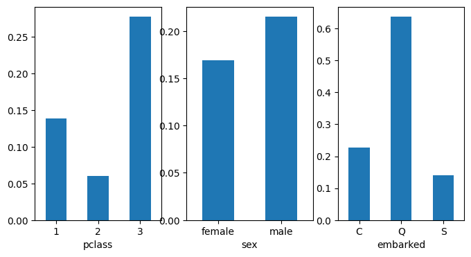

```python
fig, axes = plt.subplots(ncols=len(categories), figsize=(8,4))

for i, cat in enumerate(categories):
    (
        df
        .groupby(cat, observed=False)
        .agg(missing=('age', lambda x: x.isnull().mean()))
        .plot.bar(legend=False, rot=0, ax=axes[i])
    )
```

You can also investigate the impact of combinations of categorical variable keys on data being missing. We can for instance have a look at how the combinations of `pclass` and `embark` impact `age`s being missing. Having a good understaning of this might lead to better imputation strategies.

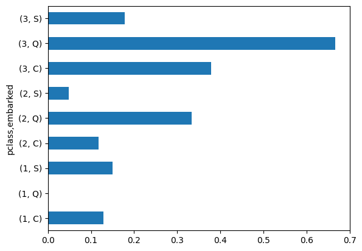

```python
(
    df
    .groupby(['pclass', 'embarked'], observed=False)
    .agg(missing=('age', lambda x: x.isnull().mean()))
    .plot.barh(legend=False)
)
```

You can also visualize this in heatmap. This can be especially helpful if your categorical have may levels (keys). As often, you have to do some further preparation of your data to get a proper visual.

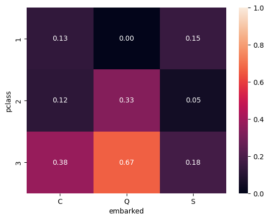

```python
(
    df
    .groupby(['pclass', 'embarked'], observed=False)
    .agg(missing=('age', lambda x: x.isnull().mean()))
    .unstack(1)
    .droplevel(level=0, axis=1)
    .pipe(sns.heatmap, vmin=0, vmax=1, annot=True, fmt=".2f")
);
```

## Analyzing Sales Data

```python
sales = pd.read_csv('sales.csv', skiprows=17, sep=';', decimal=',', parse_dates=[1], dayfirst=True)
# sales = pd.read_csv('CustomerSales.csv', usecols=[0,4,5,10,13,15,16,17,18], parse_dates=[3])
sales
```

|  | orderno | orderdate | empno | name | custno | city | regioncode | prodno | proddesc | catdesc | quantity | linetotal |
| --- | --- | --- | --- | --- | --- | --- | --- | --- | --- | --- | --- | --- |
| 0 | 1001 | 2017-01-06 | 805 | Harrie | 15 | Veghel | GVGH | 408 | Fruit Yogurt Mango | Dairy Products | 9 | 146.25 |
| 1 | 1002 | 2017-01-07 | 805 | Harrie | 16 | Eindhoven | REHV | 407 | Caviar | Luxury Products | 6 | 77.70 |
| 2 | 1002 | 2017-01-07 | 805 | Harrie | 16 | Eindhoven | REHV | 410 | Full Yogurt | Dairy Products | 15 | 315.00 |
| 3 | 1003 | 2017-01-08 | 806 | Karel | 13 | Helmond | RHMD | 401 | Organic Soymilk Sweetened | Organic Products | 18 | 387.00 |
| 4 | 1004 | 2017-01-14 | 806 | Karel | 19 | Veghel | GVGH | 406 | Foie Gras | Luxury Products | 7 | 52.50 |
| ... | ... | ... | ... | ... | ... | ... | ... | ... | ... | ... | ... | ... |
| 525 | 1436 | 2019-12-17 | 806 | Karel | 12 | Eindhoven | REHV | 402 | Organic Soy Custard | Organic Products | 9 | 333.00 |
| 526 | 1437 | 2019-12-22 | 804 | Bertha | 12 | Eindhoven | REHV | 404 | Organic Soymilk | Organic Products | 17 | 212.50 |
| 527 | 1437 | 2019-12-22 | 804 | Bertha | 12 | Eindhoven | REHV | 405 | Sweetbread | Luxury Products | 3 | 26.85 |
| 528 | 1438 | 2019-12-26 | 806 | Karel | 16 | Eindhoven | REHV | 402 | Organic Soy Custard | Organic Products | 6 | 222.00 |
| 529 | 1439 | 2019-12-26 | 804 | Bertha | 15 | Veghel | GVGH | 407 | Caviar | Luxury Products | 11 | 142.45 |

530 rows × 12 columns

```python
sales.info()
```

```
<class 'pandas.core.frame.DataFrame'>
RangeIndex: 530 entries, 0 to 529
Data columns (total 12 columns):
 #   Column      Non-Null Count  Dtype
---  ------      --------------  -----
 0   orderno     530 non-null    int64
 1   orderdate   530 non-null    datetime64[ns]
 2   empno       530 non-null    int64
 3   name        530 non-null    object
 4   custno      530 non-null    int64
 5   city        530 non-null    object
 6   regioncode  530 non-null    object
 7   prodno      530 non-null    int64
 8   proddesc    530 non-null    object
 9   catdesc     530 non-null    object
 10  quantity    530 non-null    int64
 11  linetotal   530 non-null    float64
dtypes: datetime64[ns](1), float64(1), int64(5), object(5)
memory usage: 49.8+ KB
```

### Query - How many lines have our orders?

```python
(
    sales                           # -> DataFrame
    .value_counts('orderno')       # DataFrame.value_counts() -> Series
    .value_counts()                 # Series.value_counts() -> Series
    .rename_axis('nrLines')         # Series.rename_axis() -> Series
    .reset_index(name='nrOrders')   # Series.reset_index(drop=False)-> DataFrame
)
```

|  | nrLines | nrOrders |
| --- | --- | --- |
| 0 | 1 | 387 |
| 1 | 2 | 27 |
| 2 | 3 | 14 |
| 3 | 4 | 9 |
| 4 | 6 | 1 |
| 5 | 5 | 1 |

#### Show in a visual the daily sales in 2019

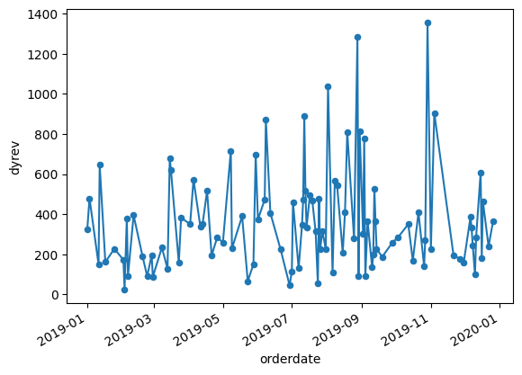

```python
fig, ax = plt.subplots(nrows=1, ncols=1)
df_daily = (
    sales
    .query('"20190101" <= orderdate <= "20191231"')
    .groupby('orderdate', as_index=False)
    .agg(dyrev = ('linetotal', 'sum'))
)
df_daily.plot.scatter(x='orderdate', y='dyrev', ax=ax, legend=False)
df_daily.plot.line(x='orderdate', y='dyrev', ax=ax, legend=False)
```

As ypu can see, this graph doesn't mirror reality: it just connect 2 subsequent days with sales, assuming that possible days between had sales values on the connecting line. That is of course wrong: missing days in the data set had no sales at all! We can make that obvious by interpolating missing days with zero sales value using a (daily) resampler:

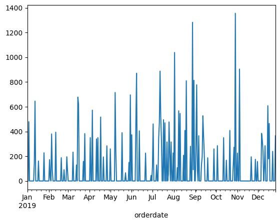

```python
(
    sales
    .query('"20190101" <= orderdate <= "20191231"')
    .set_index('orderdate')
    .resample('D')['linetotal']
    .sum()
    .plot.line()
)
```

You can resample a time series database on various sample frequencies as demonstrated in the following plot:

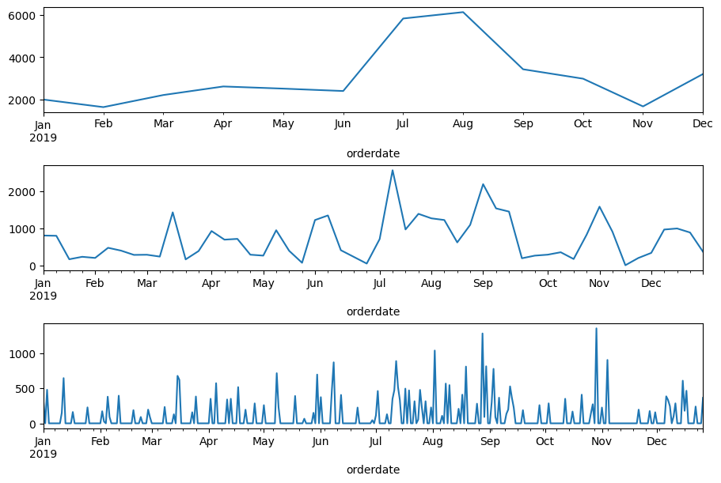

```python
frequencies = ['M', 'W', 'D']
fig, ax = plt.subplots(3, 1, figsize=(9,6), layout='constrained')
dysales = sales.query('"20190101" <= orderdate <= "20191231"').set_index('orderdate')
for i, freq in enumerate(frequencies):
    dysales.resample(freq).linetotal.sum().plot.line(ax=ax[i])
```

We use `cumsum()` for cumulative sums. It's a strange function that depends for its order on the index.

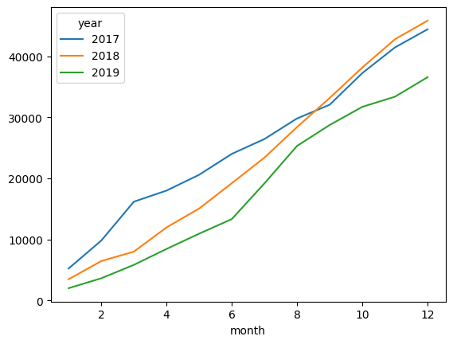

```python
(
    sales
    .assign(year=sales.orderdate.dt.year , month=sales.orderdate.dt.month)
    .groupby(['year', 'month'])['linetotal']
    .sum()
    .groupby(level=0)   # we want to group on year: it's the first (0) level of the index
    .cumsum()
    .unstack(level=0)
    .plot.line()
)
```

#### Now it's your turn

Show in a visual how average daily sales for all weekdays (Mon-Sun) differ over the years. Keep in mind that days without sales do contribute to the mean daily sales of a weekday. Phrased differently: Show how mean daily sales on Mondays, Tuesdays, etc. have different values in different years.

```python
sales = pd.read_csv('sales.csv', skiprows=17, sep=';', decimal=',', parse_dates=[1], dayfirst=True)
sales
```

|  | orderno | orderdate | empno | name | custno | city | regioncode | prodno | proddesc | catdesc | quantity | linetotal |
| --- | --- | --- | --- | --- | --- | --- | --- | --- | --- | --- | --- | --- |
| 0 | 1001 | 2017-01-06 | 805 | Harrie | 15 | Veghel | GVGH | 408 | Fruit Yogurt Mango | Dairy Products | 9 | 146.25 |
| 1 | 1002 | 2017-01-07 | 805 | Harrie | 16 | Eindhoven | REHV | 407 | Caviar | Luxury Products | 6 | 77.70 |
| 2 | 1002 | 2017-01-07 | 805 | Harrie | 16 | Eindhoven | REHV | 410 | Full Yogurt | Dairy Products | 15 | 315.00 |
| 3 | 1003 | 2017-01-08 | 806 | Karel | 13 | Helmond | RHMD | 401 | Organic Soymilk Sweetened | Organic Products | 18 | 387.00 |
| 4 | 1004 | 2017-01-14 | 806 | Karel | 19 | Veghel | GVGH | 406 | Foie Gras | Luxury Products | 7 | 52.50 |
| ... | ... | ... | ... | ... | ... | ... | ... | ... | ... | ... | ... | ... |
| 525 | 1436 | 2019-12-17 | 806 | Karel | 12 | Eindhoven | REHV | 402 | Organic Soy Custard | Organic Products | 9 | 333.00 |
| 526 | 1437 | 2019-12-22 | 804 | Bertha | 12 | Eindhoven | REHV | 404 | Organic Soymilk | Organic Products | 17 | 212.50 |
| 527 | 1437 | 2019-12-22 | 804 | Bertha | 12 | Eindhoven | REHV | 405 | Sweetbread | Luxury Products | 3 | 26.85 |
| 528 | 1438 | 2019-12-26 | 806 | Karel | 16 | Eindhoven | REHV | 402 | Organic Soy Custard | Organic Products | 6 | 222.00 |
| 529 | 1439 | 2019-12-26 | 804 | Bertha | 15 | Veghel | GVGH | 407 | Caviar | Luxury Products | 11 | 142.45 |

530 rows × 12 columns

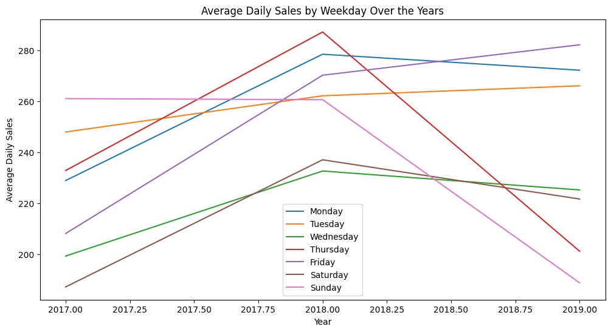

```python
import pandas as pd
import matplotlib.pyplot as plt

# Ensure that the 'orderdate' column is in datetime format
sales['orderdate'] = pd.to_datetime(sales['orderdate'])

# Extract the year and weekday from the 'orderdate' column
sales['Year'] = sales['orderdate'].dt.year
sales['Weekday'] = sales['orderdate'].dt.weekday  # Monday is 0, Sunday is 6

# Calculate average daily sales for each weekday in each year
avg_daily_sales = sales.groupby(['Year', 'Weekday'])['linetotal'].mean().unstack()

# Define the weekdays for labeling
weekdays = ['Monday', 'Tuesday', 'Wednesday', 'Thursday', 'Friday', 'Saturday', 'Sunday']

# Create a line chart
plt.figure(figsize=(12, 6))
for weekday in range(7):
    plt.plot(avg_daily_sales.index, avg_daily_sales[weekday], label=weekdays[weekday])

# Label the chart
plt.title('Average Daily Sales by Weekday Over the Years')
plt.xlabel('Year')
plt.ylabel('Average Daily Sales')
plt.legend()

# Show the chart
plt.show()
```